# Regression Review

Kyla McConnell & Julia Müller

8/31/2020

## Regression review

In this exercise, we’ll use a Tidy Tuesday dataset to get back into regression models to help us understand mixed effects models, which we’ll get into within the next few sessions.

First, take a look at the dataset (more info here: https://github.com/rfordatascience/tidytuesday/blob/master/data/2020/2020-07-07/readme.md)

```r
library(tidyverse)
library(tidymodels)
library(corrplot)
library(car)
library(dotwhisker)
library(rms)

coffee <- readr::read_csv('https://raw.githubusercontent.com/rfordatascience/tidytuesday/master/data/2020/2020-07-07/coffee_ratings.csv')
```

### Data wrangling

Starting off with a small data wrangling challenge: a) Only keep the variables total_cup_points, species, country_of_origin, processing_method, aroma, flavor, aftertaste, acidity, body, balance, uniformity, clean_cup, sweetness, and cupper_points b) Convert species and country_of_origin to factors c) Save the resulting data frame as “coffee”. d) Additionally, create a new dataset called “arabica” which only contains arabica beans.

```r
coffee <- coffee %>%
  select(c(total_cup_points, species, country_of_origin, processing_method, aroma, flavor, aftertaste, acidity, body, balance, uniformity, clean_cup, sweetness, cupper_points)) %>%
  mutate(species = factor(species),
         country = factor(country_of_origin))

arabica <- coffee %>%
  filter(species == "Arabica")
```

### Modeling

Using this data, we’d like to answer the following questions: (1) For the arabica beans only: Do ratings for aroma, flavour, balance, and clean_cup predict the overall rating (total_cup_points) of the coffee? (2) Can we use the variables acidity, sweetness, clean_cup, and balance to predict the type of bean?

For one of the hypotheses above, think about how you could use a regression model to answer the question. You may have to wrangle a bit more first.

First, do some exploratory data analysis about your question. This may include some descriptive statistics, some graphing, (tidyverse) summarizing, checking out correlations, etc.:

#### Question 1

```r
#Look at means of each group (rounded to the 10s for a better overview)
arabica %>%
  group_by(round(total_cup_points/10, 0)) %>%
  summarise(mean(aroma), mean(flavor), mean(balance), mean(clean_cup))
```

```
## # A tibble: 5 x 5
##   `round(total_cu… `mean(aroma)` `mean(flavor)` `mean(balance)` `mean(clean_cup…
##              <dbl>         <dbl>          <dbl>           <dbl>            <dbl>
## 1                0          0              0               0                0
## 2                6          7.38           6.62            6.38             3.66
## 3                7          7.00           6.77            6.8              6.77
## 4                8          7.54           7.49            7.50             9.91
## 5                9          8.08           8.13            8.04             9.99
```

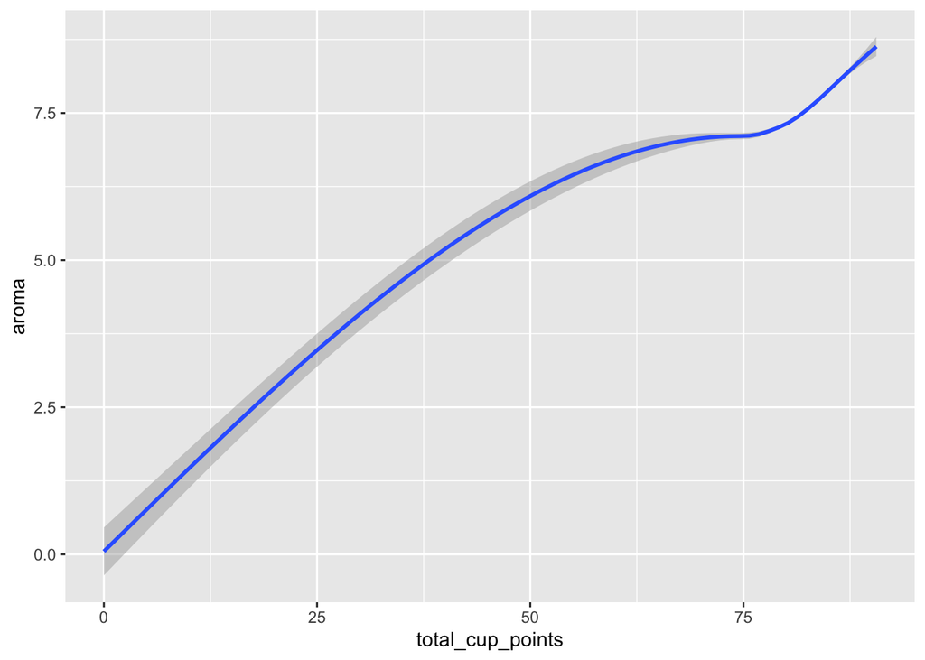

```r
#Plot line graphs of predictors vs. DV
ggplot(aes(x=total_cup_points, y=aroma), data=arabica) +
  geom_smooth()
```

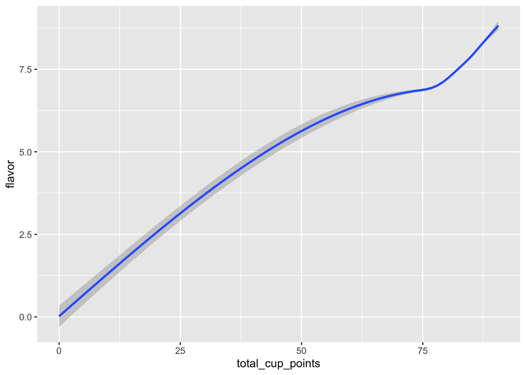

```r
ggplot(aes(x=total_cup_points, y=flavor), data=arabica) +
  geom_smooth()
```

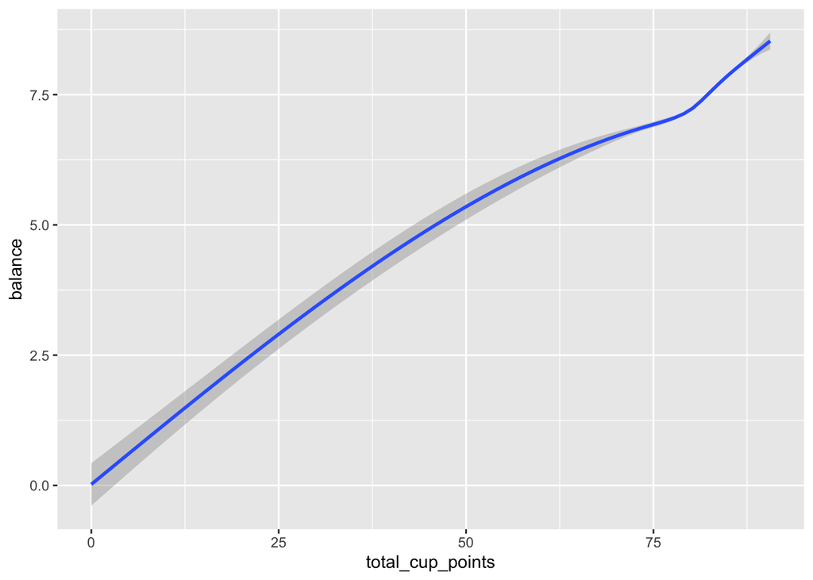

```r
ggplot(aes(x=total_cup_points, y=balance), data=arabica) +
  geom_smooth()
```

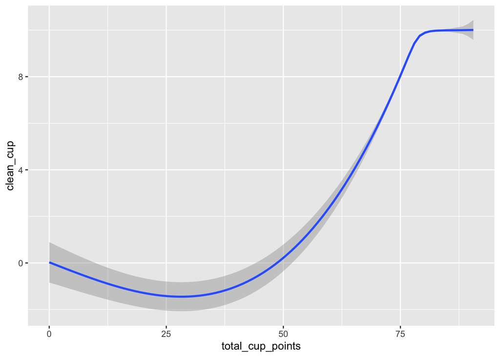

```r
ggplot(aes(x=total_cup_points, y=clean_cup), data=arabica) +
  geom_smooth()
```

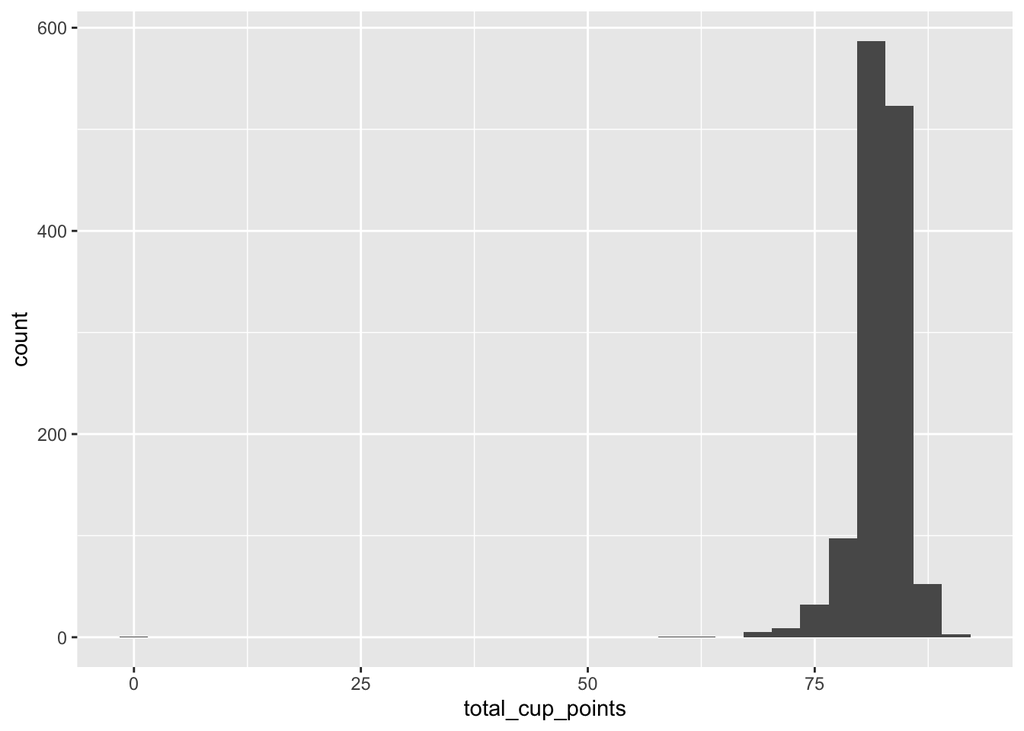

```r
#Look at distribution of DV
ggplot(aes(x=total_cup_points), data=arabica) +
  geom_histogram()
```

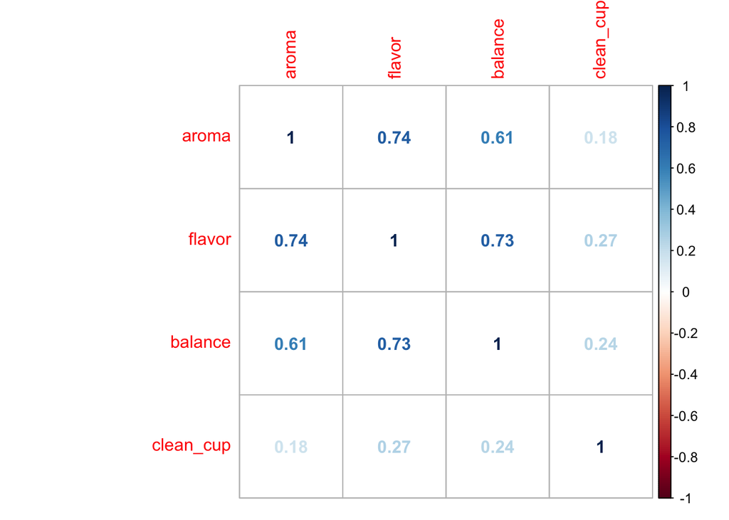

```r
#On the histogram above, we can see that some points are 0, which might mess up our model
arabica <- arabica %>%
  filter(total_cup_points > 1)

#Check out correlation of predictors
arabica %>%
  select(aroma, flavor, balance, clean_cup) %>%
  cor() %>%
  corrplot(method="number")
```

Then prepare your predictors and fit the most appropriate type of model:

```r
arabica <- arabica %>%
  mutate(aroma_z = scale(aroma, center = TRUE, scale = TRUE),
         flavor_z = scale(flavor, center = TRUE, scale = TRUE),
         balance_z = scale(balance, center = TRUE, scale = TRUE),
         clean_cup_z = scale(clean_cup, center = TRUE, scale = TRUE))

arabica_model_full <- lm(total_cup_points ~ balance_z + aroma_z + flavor_z + clean_cup_z, data = arabica)

tidy(arabica_model_full) %>%
  mutate(estimate = round(estimate, 2))
```

```
## # A tibble: 5 x 5
##   term        estimate std.error statistic   p.value
##   <chr>          <dbl>     <dbl>     <dbl>     <dbl>
## 1 (Intercept)    82.2     0.0228    3598.  0.
## 2 balance_z       0.78    0.0339      23.0 1.16e- 98
## 3 aroma_z         0.39    0.0344      11.2 6.18e- 28
## 4 flavor_z        1.09    0.0404      27.0 1.20e-127
## 5 clean_cup_z     1.08    0.0238      45.6 5.59e-272
```

```r
#Collinearity looks fine below but is borderline... Otherwise, could have tried a reduced model
arabica_model_1 <- lm(total_cup_points ~ aroma_z + clean_cup_z, data = arabica)
arabica_model_2 <- lm(total_cup_points ~ flavor_z + clean_cup_z, data = arabica)
arabica_model_3 <- lm(total_cup_points ~ balance_z + clean_cup_z, data = arabica)

AIC(arabica_model_1, arabica_model_2, arabica_model_3)
```

```
##                 df      AIC
## arabica_model_1  4 4644.639
## arabica_model_2  4 3813.906
## arabica_model_3  4 4309.706
```

And check the assumptions:

```r
## Collinearity (should be under 10, or under 3/4 if you want to be more strict)
vif(arabica_model_full)
```

```
##   balance_z     aroma_z    flavor_z clean_cup_z
##    2.205672    2.262166    3.123701    1.083180
```

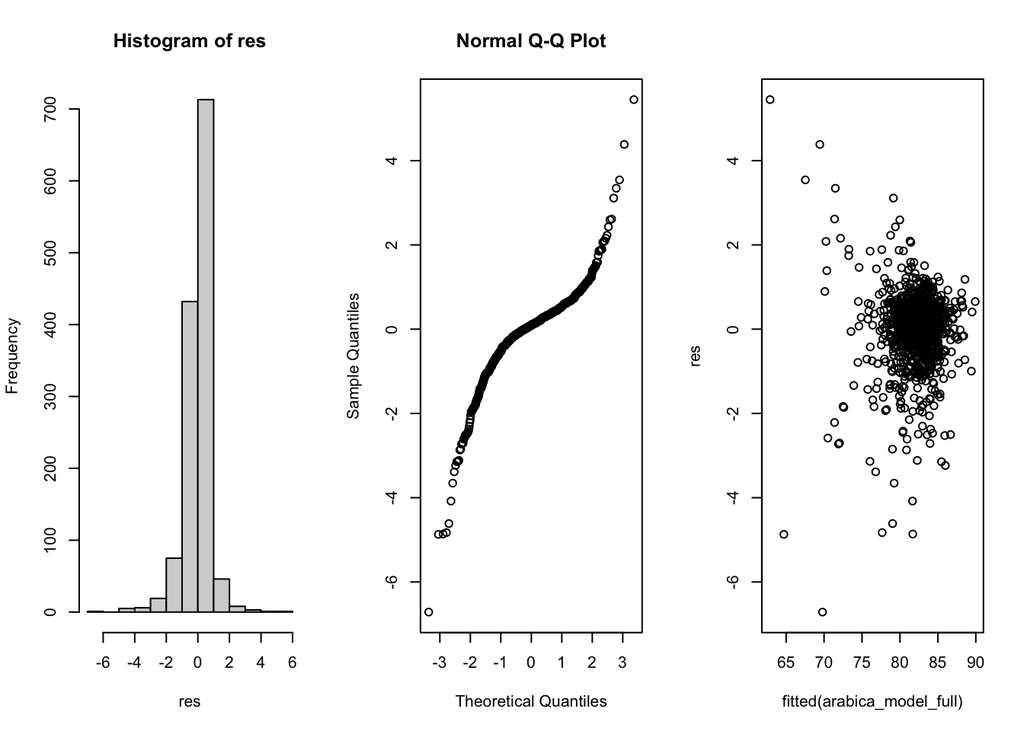

```r
## Check distribution of residuals a la Winter 2020 p110
res <- residuals(arabica_model_full)
par(mfrow = c(1,3))

###histogram looks ok
hist(res)

###QQ plot
qqnorm(res)

###Resids look ok, but looks like removing outliers might have improved our fit (i.e. the 65 score)
plot(fitted(arabica_model_full), res)
```

Check model fit. If appropriate, use predict() to see what the model predicts for different values:

```r
#(1)
## Measures of fit (r-squared, etc.)
glance(arabica_model_full)
```

```
## # A tibble: 1 x 12
##   r.squared adj.r.squared sigma statistic p.value    df logLik   AIC   BIC
##       <dbl>         <dbl> <dbl>     <dbl>   <dbl> <dbl>  <dbl> <dbl> <dbl>
## 1     0.906         0.905 0.827     3129.       0     4 -1607. 3226. 3257.
## # … with 3 more variables: deviance <dbl>, df.residual <int>, nobs <int>
```

```r
## Predict new values
arabica_model_raw <- lm(total_cup_points ~ balance + aroma + flavor + clean_cup, data = arabica)
predictions <- tibble(balance = seq(0,10), flavor = seq(0,10), aroma = seq(0,10), clean_cup = seq(0,10))
my_coffee <- tibble(balance = 6, flavor = 8, aroma = 9, clean_cup = 4)
my_coffee$predicted_cupscore <- round(predict(arabica_model_raw, my_coffee), 0)
my_coffee
```

```
## # A tibble: 1 x 5
##   balance flavor aroma clean_cup predicted_cupscore
##     <dbl>  <dbl> <dbl>     <dbl>              <dbl>
## 1       6      8     9         4                 73
```

#### Question 2

First, do some exploratory data analysis about your question. This may include some descriptive statistics, some graphing, (tidyverse) summarizing, checking out correlations, etc.:

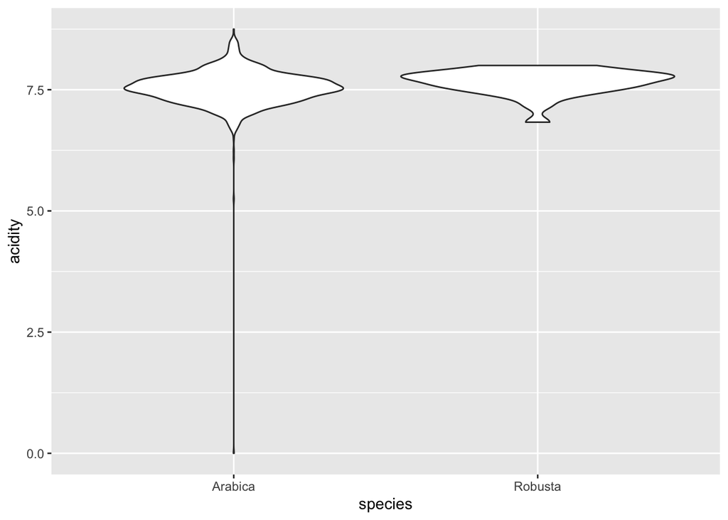

```r
#Plot graphs of predictors vs. DV

coffee %>% ggplot() +
  aes(x = species, y = acidity) +
  geom_violin()
```

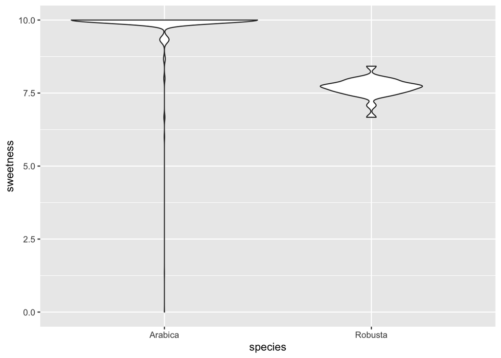

```r
coffee %>% ggplot() +
  aes(x = species, y = sweetness) +
  geom_violin()
```

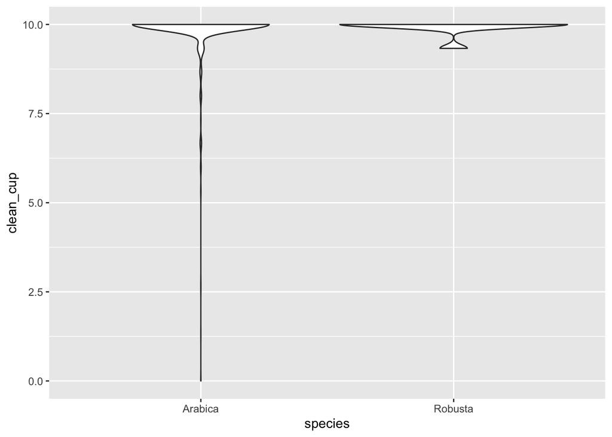

```r
coffee %>% ggplot() +
  aes(x = species, y = clean_cup) +
  geom_violin()
```

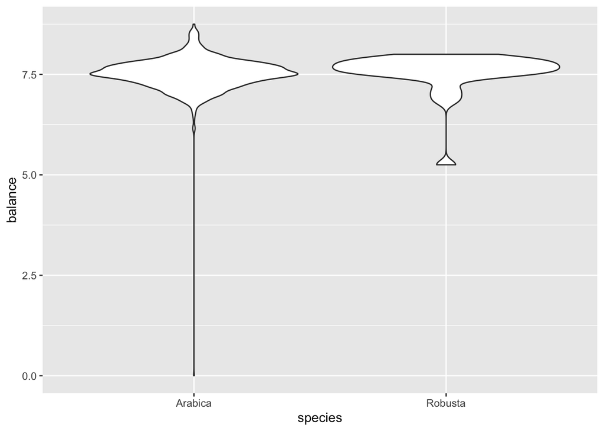

```r
coffee %>% ggplot() +
  aes(x = species, y = balance) +
  geom_violin()
```

```r
#In the violin plot, we can see that some points are 0, which might mess up our model
coffee <- coffee %>%
  filter(aroma > 6, clean_cup > 6)
```

Check correlations of predictors

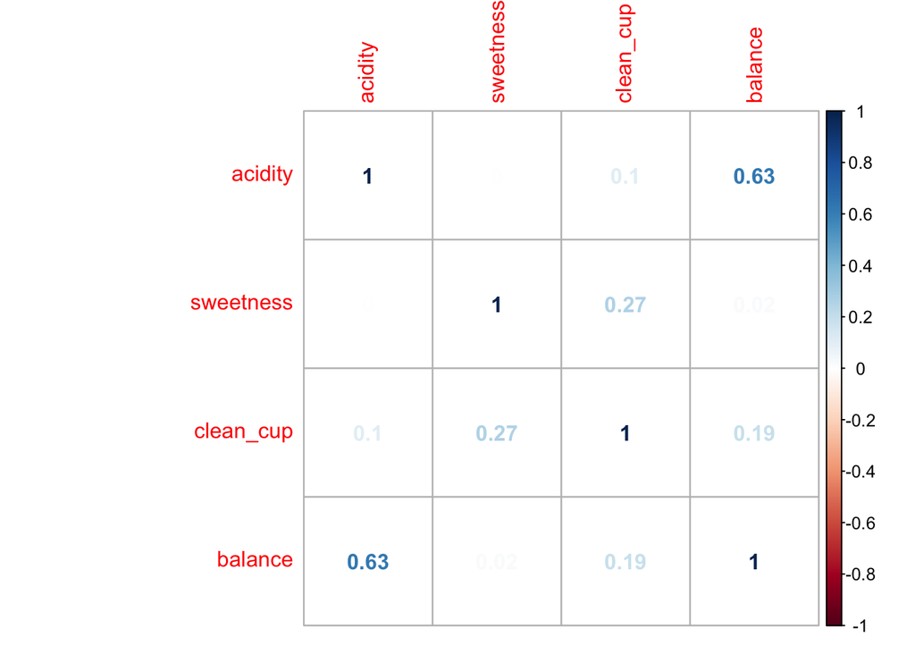

```r
coffee %>%
  select(acidity, sweetness, clean_cup, balance) %>%
  cor() %>%
  corrplot(method="number")
```

Balance and acidity are correlated, but logistic regressions can handle some colinearity.

Centering and scaling predictors:

```r
coffee <- coffee %>%
  mutate(acidity_z = scale(acidity, center = TRUE, scale = TRUE),
         sweetness_z = scale(sweetness, center = TRUE, scale = TRUE),
         balance_z = scale(balance, center = TRUE, scale = TRUE),
         clean_cup_z = scale(clean_cup, center = TRUE, scale = TRUE))
```

Specifying model:

```r
species_model_1 <- glm(species ~ sweetness_z + clean_cup_z,
                       data = coffee, family = binomial)
species_model_2 <- glm(species ~ acidity_z + sweetness_z + clean_cup_z,
                       data = coffee, family = binomial)
species_model_3 <- glm(species ~ acidity_z + sweetness_z + clean_cup_z + balance_z,
                       data = coffee, family = binomial)

anova(species_model_1, species_model_2, species_model_3, test = "Chisq")
```

```
## Analysis of Deviance Table
##
## Model 1: species ~ sweetness_z + clean_cup_z
## Model 2: species ~ acidity_z + sweetness_z + clean_cup_z
## Model 3: species ~ acidity_z + sweetness_z + clean_cup_z + balance_z
##   Resid. Df Resid. Dev Df Deviance Pr(>Chi)
## 1      1321     74.059
## 2      1320     72.385  1   1.6741   0.1957
## 3      1319     68.990  1   3.3947   0.0654 .
## ---
## Signif. codes:  0 '***' 0.001 '**' 0.01 '*' 0.05 '.' 0.1 ' ' 1
```

```r
species_lrm_model <- lrm(species ~ sweetness_z + clean_cup_z,
                       data = coffee)

summary(species_model_1)
```

```
##
## Call:
## glm(formula = species ~ sweetness_z + clean_cup_z, family = binomial,
##     data = coffee)
##
## Deviance Residuals:
##      Min        1Q    Median        3Q       Max
## -2.97557  -0.06091  -0.06091  -0.06091   1.71529
##
## Coefficients:
##             Estimate Std. Error z value Pr(>|z|)
## (Intercept)  -6.3598     0.6384  -9.962  < 2e-16 ***
## sweetness_z  -1.5456     0.1673  -9.237  < 2e-16 ***
## clean_cup_z   1.9607     0.6625   2.960  0.00308 **
## ---
## Signif. codes:  0 '***' 0.001 '**' 0.01 '*' 0.05 '.' 0.1 ' ' 1
##
## (Dispersion parameter for binomial family taken to be 1)
##
##     Null deviance: 271.351  on 1323  degrees of freedom
## Residual deviance:  74.059  on 1321  degrees of freedom
## AIC: 80.059
##
## Number of Fisher Scoring iterations: 9
```

```r
confint(species_model_1)
```

```
##                 2.5 %    97.5 %
## (Intercept) -7.884733 -5.301395
## sweetness_z -1.924190 -1.252682
## clean_cup_z  0.862811  3.501518
```

```r
species_lrm_model
```

```
## Logistic Regression Model
##
##  lrm(formula = species ~ sweetness_z + clean_cup_z, data = coffee)
##
##                         Model Likelihood    Discrimination    Rank Discrim.
##                               Ratio Test           Indexes          Indexes
##  Obs          1324    LR chi2     197.29    R2       0.747    C       0.996
##   Arabica     1296    d.f.             2    g        1.144    Dxy     0.992
##   Robusta       28    Pr(> chi2) <0.0001    gr       3.140    gamma   0.992
##  max |deriv| 1e-05                          gp       0.038    tau-a   0.041
##                                             Brier    0.007
##
##                 Coef    S.E.   Wald Z Pr(>|Z|)
##  Intercept      -6.3598 0.6384 -9.96  <0.0001
##  sweetness_z[1] -1.5456 0.1673 -9.24  <0.0001
##  clean_cup_z[1]  1.9607 0.6625  2.96  0.0031
##
```

And check the assumptions:

```r
rms::vif(species_lrm_model)
```

```
## sweetness_z[1] clean_cup_z[1]
##        1.18058        1.18058
```

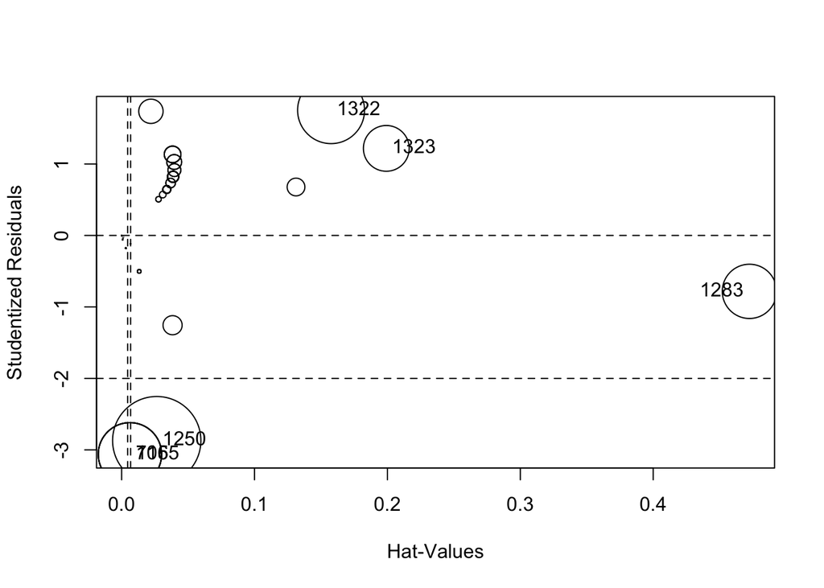

```
##         StudRes        Hat      CookD
## 716  -3.0617312 0.00625166 0.17447448
## 1055 -3.0617312 0.00625166 0.17447448
## 1250 -2.8702085 0.02641477 0.33895340
## 1283 -0.7821663 0.47242321 0.12828844
## 1322  1.7525188 0.15759532 0.19477116
## 1323  1.2182443 0.19916173 0.09130664
```

```r
car::influencePlot(species_model_1)
```

```r
coffee[c(716, 1055, 1250, 1283, 1322, 1323),]
```

```
## # A tibble: 6 x 19
##   total_cup_points species country_of_orig… processing_meth… aroma flavor
##              <dbl> <fct>   <chr>            <chr>            <dbl>  <dbl>
## 1             82.3 Arabica Brazil           Natural / Dry     7.75   8.08
## 2             80.7 Arabica Colombia         Natural / Dry     7.67   7.5
## 3             77.6 Arabica United States (… Natural / Dry     7.58   7.67
## 4             74.4 Arabica United States (… Natural / Dry     7.5    7.25
## 5             77.2 Robusta United States    Natural / Dry     7.33   7.33
## 6             75.1 Robusta India            Natural / Dry     7.42   6.83
## # … with 13 more variables: aftertaste <dbl>, acidity <dbl>, body <dbl>,
## #   balance <dbl>, uniformity <dbl>, clean_cup <dbl>, sweetness <dbl>,
## #   cupper_points <dbl>, country <fct>, acidity_z[,1] <dbl>,
## #   sweetness_z[,1] <dbl>, balance_z[,1] <dbl>, clean_cup_z[,1] <dbl>
```

Check model fit. Use predict() to see the performance:

```r
probability.table <- fitted(species_model_1)
head(probability.table)
```

```
##           1           2           3           4           5           6
## 0.001853347 0.001853347 0.001853347 0.001853347 0.001853347 0.001853347
```

```r
coffee$predicted <- predict(species_model_1, newdata = coffee)
coffee <- coffee %>%
  mutate(pred_cat = if_else(predicted > 0, "Robusta", "Arabica"))

coffee %>% select(species, predicted, pred_cat)
```

```
## # A tibble: 1,324 x 3
##    species predicted pred_cat
##    <fct>       <dbl> <chr>
##  1 Arabica     -6.29 Arabica
##  2 Arabica     -6.29 Arabica
##  3 Arabica     -6.29 Arabica
##  4 Arabica     -6.29 Arabica
##  5 Arabica     -6.29 Arabica
##  6 Arabica     -6.29 Arabica
##  7 Arabica     -6.29 Arabica
##  8 Arabica     -4.14 Arabica
##  9 Arabica     -4.14 Arabica
## 10 Arabica     -6.29 Arabica
## # … with 1,314 more rows
```

```r
coffee %>% filter(species != pred_cat) %>% select(species, pred_cat)
```

```
## # A tibble: 8 x 2
##   species pred_cat
##   <fct>   <chr>
## 1 Arabica Robusta
## 2 Arabica Robusta
## 3 Arabica Robusta
## 4 Arabica Robusta
## 5 Arabica Robusta
## 6 Arabica Robusta
## 7 Robusta Arabica
## 8 Robusta Arabica
```

```r
ctable <- table(coffee$species, coffee$pred_cat)
ctable
```

```
##
##           Arabica Robusta
##   Arabica    1290       6
##   Robusta       2      26
```

```r
round((sum(diag(ctable))/sum(ctable))*100,2)
```

```
## [1] 99.4
```

### Graphing

For your hypothesis above, graph the model output with a dot-whisker plot or other appropriate plot style. Use the link below and Ch 11 in Winter 2020: https://cran.r-project.org/web/packages/dotwhisker/vignettes/dotwhisker-vignette.html

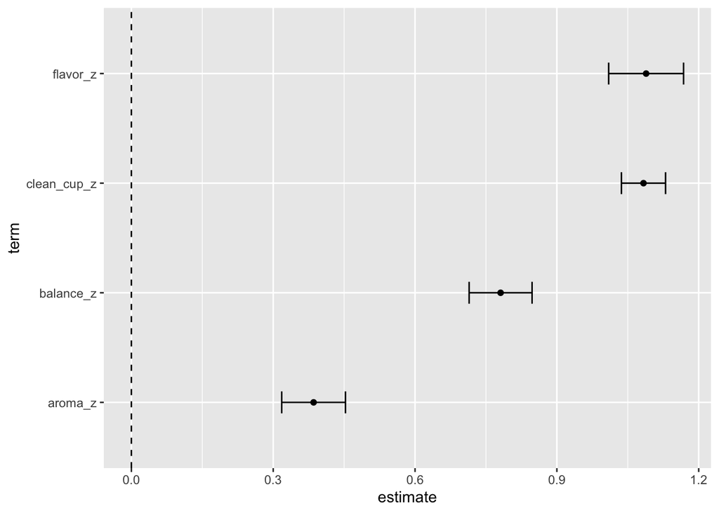

```r
#(1)
mycoefs <- arabica_model_full %>%
  tidy(conf.int = TRUE) %>%
  filter(term != "(Intercept)")

mycoefs %>%
  ggplot(aes(x=term, y=estimate)) +
  geom_point() +
  geom_errorbar(aes(ymin=conf.low, ymax=conf.high),
                width = 0.2) +
  geom_hline(yintercept = 0, linetype = 2) +
  coord_flip()
```

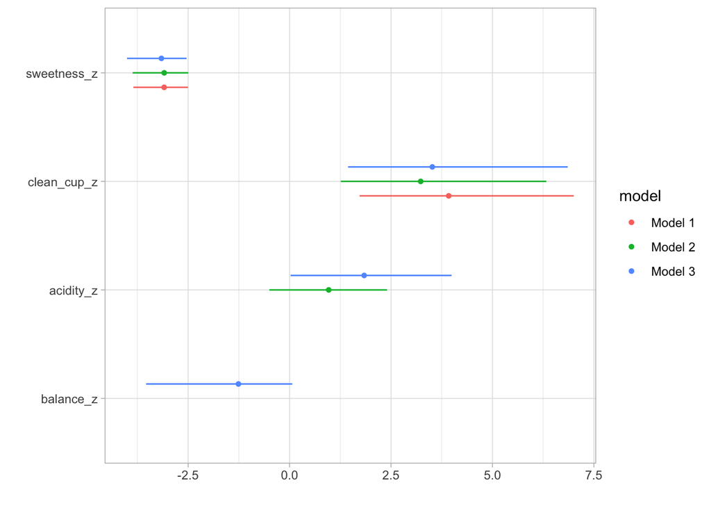

```r
#(2)
dwplot(list(species_model_1, species_model_2, species_model_3)) +
  theme_light()
```

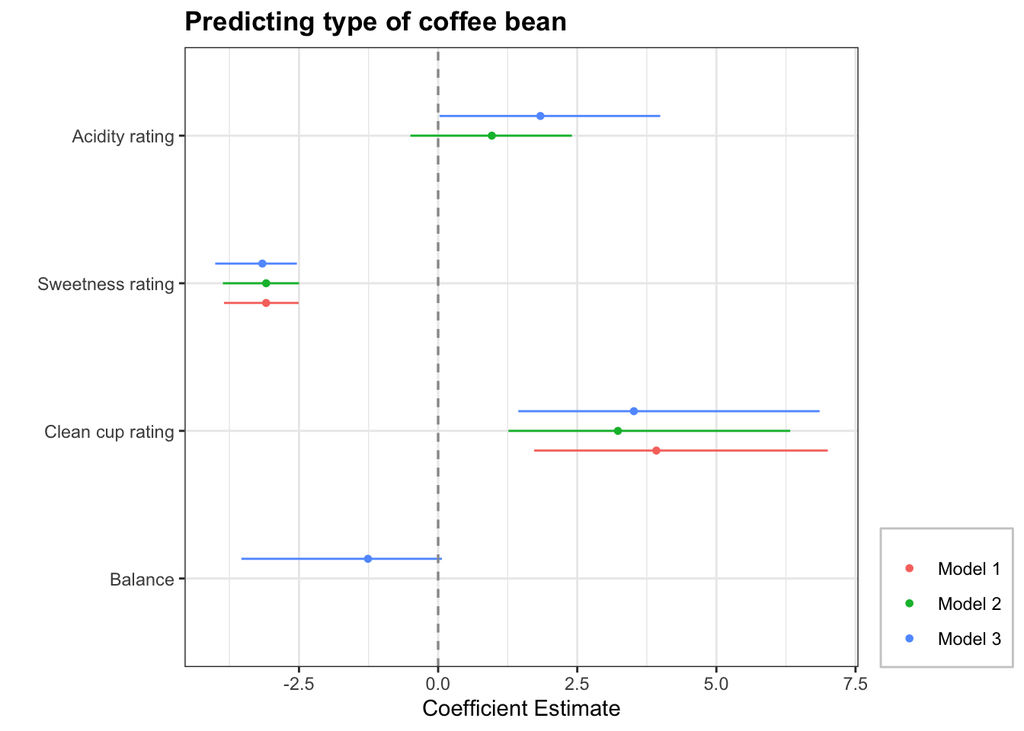

```r
dwplot(list(species_model_1, species_model_2, species_model_3),
       vline = geom_vline(xintercept = 0, colour = "grey60", linetype = 2)) %>%
    relabel_predictors(c(acidity_z = "Acidity rating",
                         sweetness_z = "Sweetness rating",
                         clean_cup_z = "Clean cup rating",
                         balance_z = "Balance")) +
     theme_bw() + xlab("Coefficient Estimate") + ylab("") +
     geom_vline(xintercept = 0, colour = "grey60", linetype = 2) +
     ggtitle("Predicting type of coffee bean") +
     theme(plot.title = element_text(face="bold"),
           legend.justification = c(0, 0),
           legend.background = element_rect(colour="grey80"),
           legend.title = element_blank())
```

### Reporting

Now imagine that you want to present your work above. Write your analysis using precise and accurate statistical terminology.

If you have time, make a nice markdown file with the important output, graphs and interpretation (without showing any unneccesary code.)